# Machine Learning Group Assignment 1

## Team A3:

Yuxi Fu  
Jiaxuan Lyu  
Maria Tsotalou  
Qian Zhang  
Jiaqi Chen

```python
import pandas as pd
import numpy as np
import math
from sklearn import preprocessing
from sklearn.preprocessing import StandardScaler
from sklearn.neighbors import KNeighborsClassifier
from sklearn import metrics
import matplotlib.pyplot as plt
import seaborn as sns
```

**1. Load the data file**

```python
#load the first 800 instances of the data file
wine_data = pd.read_csv("winequality-white.csv",delimiter=";", nrows =800 )
```

**2. Construct a new binary column “good wine” that indicates whether the wine is good(quality of 7 or higher) or not**

```python
# construct a new binary column “good wine" which would be true if quality >=7
wine_data["Good wine"] = np.where(wine_data['quality']>=7, 1, 0)
```

**3. Split the data into a training set(first 400 samples), a validation set (next 200 samples), test set (last 200 samples) - no suffle needed**

```python
#splitting the data
training_data, validation_data, test_data = wine_data[:400], wine_data[400:600], wine_data[600:]
```

**4. Normalises the data according to the Z-score transform**

```python
#normalises the data according to the Z-score transform
def normalises_the_data_z_score(input_data):
    data_normalised = preprocessing.scale(input_data)
    data_normalised = pd.DataFrame(data=data_normalised,columns = list(input_data.columns))
    data_normalised['Good wine'] = input_data['Good wine']
    return data_normalised
training_data_normalised = normalises_the_data_z_score(training_data)
validation_data_normalised = normalises_the_data_z_score(validation_data)
test_data_normalised = normalises_the_data_z_score(test_data)
```

**5. and 6. Loads and trains the k-Nearest Neighbours classifiers for k = 1,2, …,100 and Εvaluates each classifier using the validation data set and selects the best classifier**

The goal is to classify each wine as "good" or not good based on its other available characteristics. Consequently the Y variable will be a binary variable, which will be positive if the wine is classified as "good", while the input variables will be all the other wine characteristics except for the 'quality' column.

Taking into consideration the difference among the wine characteristics' scales we will perform the k-NN analysis on the z-score normalised input data. We note that the Y binary valuable remains intact.

We "train" the k-NN classifiers for k = 1,2,..., 100.

In order to evaluate each classifier we use the validation data set and calculate the classification error for each classifier.

```python
#Normalsied Training data
training_data_normalised_x = training_data_normalised.copy().drop(columns=['quality', 'Good wine']).values
training_data_normalised_y = training_data['Good wine']

#Normalsied Validation data
validation_data_normalised_x = validation_data_normalised.copy().drop(columns=['quality', 'Good wine']).values
validation_data_normalised_y = validation_data['Good wine']

#KNN classifier model for K=1,..,100:
scores_list = []
for k in range(1,101):
    classifier = KNeighborsClassifier(n_neighbors=k)

    #Training model using training dataset:
    classifier.fit(training_data_normalised_x, training_data_normalised_y)

    #Predicting response for validation dataset:
    validation_data_normalised_y_predicted = classifier.predict(validation_data_normalised_x)
    scores_list.append(1-metrics.accuracy_score(validation_data_normalised_y,validation_data_normalised_y_predicted,normalize=True))

#Creating dataframe for the classification errors for validation and training set
scores_list_df = pd.DataFrame(data=scores_list).rename(columns={0: "Classification error(validation data)"})
scores_list_df['k-value'] = list(range(1,101))
```

An overview of each classifier's classification error is depicted in the plot below.

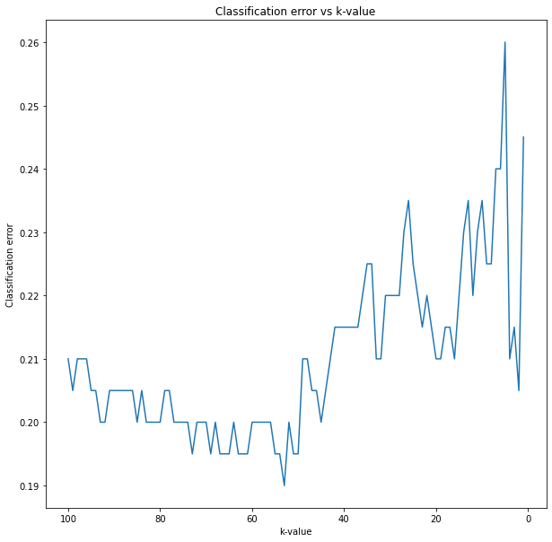

```python
# Plot the classification error
fig = plt.figure(figsize=(10,10))
plt.plot(scores_list_df['k-value'], scores_list_df['Classification error(validation data)'])
plt.gca().invert_xaxis()
plt.title('Classification error vs k-value')
plt.xlabel('k-value')
plt.ylabel('Classification error')
plt.show()
```

We consider as best classifier, the one with the lowest percentage of classification error.

```python
#Finding the classifier with the lowest classification error
best_k_value=scores_list_df['Classification error(validation data)'].idxmin()+1
print('best k-value =', best_k_value)
```

```
best k-value = 53
```

**7. Predict the generalisation error using the test data set**

```python
#Generalisation error using test set
test_data_normalised_x = test_data_normalised.copy().drop(columns=['quality', 'Good wine']).values
test_data_normalised_y = test_data['Good wine']

test_data_normalised_y_predicted = classifier.predict(test_data_normalised_x)
testing_data_error_ratio= 1-metrics.accuracy_score(test_data_normalised_y,test_data_normalised_y_predicted,normalize=True)
print('lowest classification error =', testing_data_error_ratio)
```

```
lowest classification error = 0.20999999999999996
```

**8. Try a new splitting: split the data set into a training data set (first 200 samples), a validation data set (next 200 samples), and a test data set (last 400 samples) - again, please do not shuffle the data. Then redo steps 4 to 7. What is the new generalisation error? Explain what you find**

```python
#splitting the data into training,validation and test data
training, validation, test = wine_data[:200], wine_data[200:400], wine_data[400:]

#normalising the data according to the Z-score transformation
training_normalised = normalises_the_data_z_score(training)
validation_normalised = normalises_the_data_z_score(validation)
test_normalised = normalises_the_data_z_score(test)
```

```python
training_normalised_x = training_normalised.copy().drop(columns=['quality', 'Good wine']).values
training_normalised_y = training['Good wine']

validation_normalised_x = validation_normalised.copy().drop(columns=['quality', 'Good wine']).values
validation_normalised_y = validation['Good wine']

#KNN classifier model for K=1,..,100:
scores_list2 = []
for k in range(1,101):
    classifier = KNeighborsClassifier(n_neighbors=k)
    #Training model using training dataset:
    classifier.fit(training_normalised_x, training_normalised_y)
    #Predicting response for validation dataset:
    validation_normalised_y_predicted = classifier.predict(validation_normalised_x)
    scores_list2.append(1-metrics.accuracy_score(validation_normalised_y,validation_normalised_y_predicted,normalize=True))


scores_list2_df = pd.DataFrame(data=scores_list2).rename(columns={0: "Classification error(validation data)"})
scores_list2_df['Classification error(training data)'] = scores_list2
scores_list2_df['k-value'] = list(range(1,101))
```

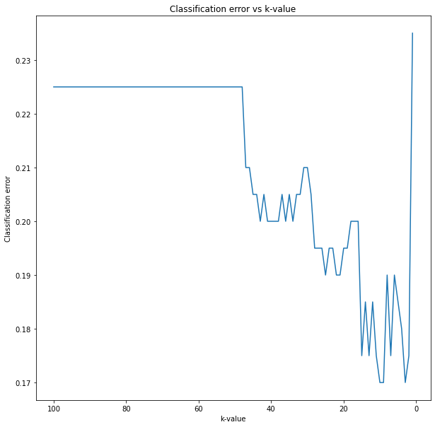

```python
# Plot the classification error
fig = plt.figure(figsize=(10,10))
plt.plot(scores_list2_df['k-value'], scores_list2_df['Classification error(validation data)'])
plt.gca().invert_xaxis()
plt.title('Classification error vs k-value')
plt.xlabel('k-value')
plt.ylabel('Classification error')
plt.show()
```

```python
#Best value of K is one that results in lowest classification error
best_k_value=scores_list2_df['Classification error(validation data)'].idxmin()+1
print('best k-value =', best_k_value)
```

```
best k-value = 3
```

```python
test_normalised_x = test_normalised.copy().drop(columns=['quality', 'Good wine']).values
test_normalised_y = test['Good wine']

test_normalised_y_predicted = classifier.predict(test_normalised_x)
testing_error_ratio= 1-metrics.accuracy_score(test_normalised_y,test_normalised_y_predicted,normalize=True)
print('lowest classification error =', testing_error_ratio)
```

```
lowest classification error = 0.21250000000000002
```

**Explain what you find**

The first split of the data into 400:200:200 results in a slightly better performance on the test set, i.e. lower generalisation error than the second split of 200:200:400. The first split has a bigger training set; thus, there are more data points, adding more information which improves the fit and leads to higher accuracy where the best classifier is k=53.

The graph for the classifier’s classification error for the 400:200:200 split of data shows that the classificationerror reaches a minimum at a larger k in comparison to the 200:200:400 split, where the best classifier is k=3.

**Evaluate whether the classifier is well-suited for the data set**

We will use Sensitivity and Specificity as measures along with the estimation misclassification rate. We will plot the confusion matrix for the classifier as well as the classification_report, which provides those metrics.

Sensitivity = (true predicted yes)/(all predicted yes) Specificity = (true predicted no)/(all actual no)

The choice of how to define "yes" it depeds on which class is considered as important. In our case the good wine is the important class and thus we will calculate the metrics based on this case.

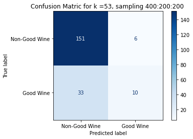

```python
#calculating classification report for K=53, 400:200:200 case
classifier = KNeighborsClassifier(n_neighbors=53)
classifier.fit(training_data_normalised_x, training_data_normalised_y)
validation_data_normalised_y_predicted = classifier.predict(validation_data_normalised_x)
test_data_normalised_y_predicted = classifier.predict(test_data_normalised_x)

labels = ["Non-Good Wine", "Good Wine"]
disp = metrics.plot_confusion_matrix(classifier, test_data_normalised_x, test_data_normalised_y, display_labels = labels, cmap=plt.cm.Blues)
disp.ax_.set_title("Confusion Matric for k =53, sampling 400:200:200 ")
```

Sensitivity = (true predicted good wine)/(all predicted good wine) = 10 / 16 Specificity = (true predicted non-good wine)/(all actual non-good wine) = 151 / (151+6)

```python
clas_rep = metrics.classification_report(test_data_normalised_y , test_data_normalised_y_predicted, target_names = labels)
print(clas_rep) #Classification report
```

```
               precision    recall  f1-score   support

Non-Good Wine       0.82      0.96      0.89       157
    Good Wine       0.62      0.23      0.34        43

     accuracy                           0.81       200
    macro avg       0.72      0.60      0.61       200
 weighted avg       0.78      0.81      0.77       200
```

The classification report provides us with the sensitivity (precision for Good wine) = 0.62 and Specificity (recall for Non-Good wine) = 0.96

```python
#calculating classification report for K=3, 200:200:400.
classifier = KNeighborsClassifier(n_neighbors= 3)
classifier.fit(training_normalised_x, training_normalised_y)#
validation_normalised_y_predicted = classifier.predict(validation_normalised_x)
test_normalised_y_predicted = classifier.predict(test_normalised_x)
```

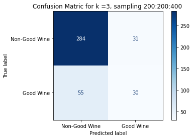

```python
labels = ["Non-Good Wine", "Good Wine"]
disp = metrics.plot_confusion_matrix(classifier, test_normalised_x, test_normalised_y, display_labels = labels, cmap=plt.cm.Blues)
disp.ax_.set_title("Confusion Matric for k =3, sampling 200:200:400 ")
```

```python
print(metrics.classification_report(test_normalised_y , test_normalised_y_predicted, target_names = labels)) #Classification report
```

```
               precision    recall  f1-score   support

Non-Good Wine       0.84      0.90      0.87       315
    Good Wine       0.49      0.35      0.41        85

     accuracy                           0.79       400
    macro avg       0.66      0.63      0.64       400
 weighted avg       0.76      0.79      0.77       400
```

The classification report provides us with the sensitivity (precision for Good wine) = 0.49 and Specificity (recall for Non-Good wine) = 0.9

Whether the classifier is suitable for the dataset depends on the purpose of our prediction.

For example for the classifier of the 400:200:200 sampling where k = 53, looking at the recall for Good quality Wines shows that good quality wine is predicted correctly 23% of the time. The sensitivity (precision of Good quality Wine) is 62%, meaning that when a good quality wine is predicted, the prediction is correct 62% of the time.

In comparison for the classifier with K=3 in the second sampling case, the confusion matrix shows that the recall value for good quality wines predicted correctly 35% of the time, which is higher than the first classifier. However, it has a lower sensitivity of 49% and a lower specificity, namely 90%.

Thus, the first classifier would be more suitable if it is important to know that the predicted good wines are indeed good, however it still has a low sensitivity rate. While the second model would be more suitable (compared to the first model, since generally speaking has a low performance) if our goal was to predict the most of good wines as possible.

On the other hand those models would be good choice, especially the first one, if our goal was to maximise the number of for Non-Good wines who are indeed predicted as Non-Good.